# Conscientiousness_Regression

Kristofer Svendsen

2026-03-20

### Introduction

This exploratory analysis will examine which demographic-based predictors are associated with higher scores on a conscientiousness measure. Conscientiousness is one of the big five personality traits–the others being openness, neuroticism, agreeableness, and extraversion. Conscientiousness is a set of personality constructs related to an individual’s propensity to be self-controlled, responsible to others, hardworking, orderly, and rule-abiding. High levels of conscientiousness are associated with high achievement in formal education, high job performance, marital stability, and a lower risk of depression [(Roberts et al., 2014)](https://pubmed.ncbi.nlm.nih.gov/23276130/).

We will be using the bfi data set from the Synthetic Aperture Personality Assessment (SAPA) web based personallity assessment project. The data consist of 2800 responses to five questions designed to assess conscientiousness as well as information about age, gender, and education.

```r
library(psych) #contains bfi data set
library(skimr)
library(tidyverse)
library(Hmisc)
library(MBESS)
library(lme4)
library(interactions)
library(RColorBrewer)
library(gtsummary)
library(lm.beta)
library(car)
```

```r
bfi.raw = bfi #Load dataset
bfi.raw <- select(bfi.raw, C1:C5, gender:age) #create subset of conscientiousness questions with gender, education and age
```

```r
#inspect data
glimpse(bfi.raw)
```

```
## Rows: 2,800
## Columns: 8
## $ C1        <int> 2, 5, 4, 4, 4, 6, 5, 3, 6, 6, 4, 5, 5, 4, 5, 5, 4, 5, 5, 1, …
## $ C2        <int> 3, 4, 5, 4, 4, 6, 4, 2, 6, 5, 3, 4, 4, 4, 5, 5, 4, 5, 4, 1, …
## $ C3        <int> 3, 4, 4, 3, 5, 6, 4, 4, 3, 6, 5, 5, 3, 4, 5, 5, 4, 5, 5, 1, …
## $ C4        <int> 4, 3, 2, 5, 3, 1, 2, 2, 4, 2, 3, 4, 2, 2, 2, 3, 4, 4, 4, 5, …
## $ C5        <int> 4, 4, 5, 5, 2, 3, 3, 4, 5, 1, 2, 5, 2, 1, 2, 5, 4, 3, 6, 6, …
## $ gender    <int> 1, 2, 2, 2, 1, 2, 1, 1, 1, 2, 1, 1, 2, 1, 1, 1, 2, 1, 2, 2, …
## $ education <int> NA, NA, NA, NA, NA, 3, NA, 2, 1, NA, 1, NA, NA, NA, 1, NA, N…
## $ age       <int> 16, 18, 17, 17, 17, 21, 18, 19, 19, 17, 21, 16, 16, 16, 17, …
```

```r
head(bfi.raw)
```

```
##       C1 C2 C3 C4 C5 gender education age
## 61617  2  3  3  4  4      1        NA  16
## 61618  5  4  4  3  4      2        NA  18
## 61620  4  5  4  2  5      2        NA  17
## 61621  4  4  3  5  5      2        NA  17
## 61622  4  4  5  3  2      1        NA  17
## 61623  6  6  6  1  3      2         3  21
```

```r
colSums(is.na(bfi.raw))
```

```
##        C1        C2        C3        C4        C5    gender education       age
##        21        24        20        26        16         0       223         0
```

We will need to reassign gender and education as factors. Also, there are many NAs present in the data set. The NAs present in question answers we will inspect further and decide between dropping or imputing; however, we will do this at the end of cleaning to see how many NAs remain. The NAs in education we will drop as we want to examine education as a predictor and our sample is large enough to handle a loss of 223 responses.

### Cleaning

```r
#remove NAs in education
bfi.raw <- filter(bfi.raw, !is.na(education)) #removes 223 entries
colSums(is.na(bfi.raw)) #verify no na in education
```

```
##        C1        C2        C3        C4        C5    gender education       age
##        21        20        17        22        16         0         0         0
```

```r
#verify and correct data types
sapply(bfi.raw, class)
```

```
##        C1        C2        C3        C4        C5    gender education       age
## "integer" "integer" "integer" "integer" "integer" "integer" "integer" "integer"
```

```r
bfi.raw$gender<- as.factor(bfi.raw$gender)
is.factor(bfi.raw$gender)
```

```
## [1] TRUE
```

```r
bfi.raw$education <- as.factor(bfi.raw$education)
is.factor(bfi.raw$education)
```

```
## [1] TRUE
```

```r
#label gender and education level

bfi.raw$gender <- factor(bfi.raw$gender,
                         levels = c(1,2),
                         labels = c("male", "female"))
summary(bfi.raw$gender)
```

```
##   male female
##    838   1739
```

```r
bfi.raw$education <- factor(bfi.raw$education,
                            levels = c(1,2,3,4,5),
                            labels = c("some HS", "HS", "some college", "college", "graduate degree"))
summary(bfi.raw$education)
```

```
##         some HS              HS    some college         college graduate degree
##             224             292            1249             394             418
```

Next, we will verify the age ranges reported. Our education responses range from “some high school” to “graduate degree”. Subsequently, there will be no upper limit to the age range (except for clear input errors) but we will set the low-end bound at 14 years of age.

```r
summary(bfi.raw$age)
```

```
##    Min. 1st Qu.  Median    Mean 3rd Qu.    Max.
##    3.00   21.00   26.00   29.72   36.00   86.00
```

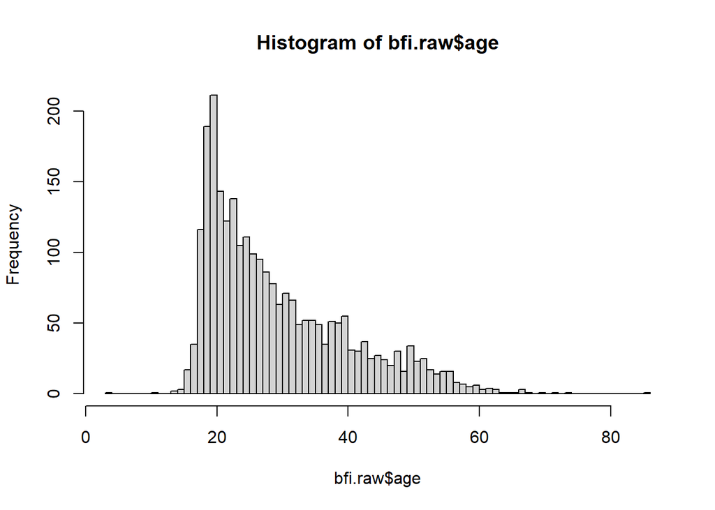

```r
hist(bfi.raw$age,
     breaks = 80)
```

```r
head(sort(bfi.raw$age), 10) #print the lowest 10 ages
```

```
##  [1]  3 11 14 14 15 15 15 16 16 16
```

```r
head(sort(bfi.raw$age, decreasing = TRUE), 10) #print the highest 10 ages
```

```
##  [1] 86 74 72 70 68 67 67 67 66 65
```

```r
bfi.raw <- filter(bfi.raw, age>11) #removes 2 entries
summary(bfi.raw)
```

```
##        C1              C2            C3              C4              C5
##  Min.   :1.000   Min.   :1.0   Min.   :1.000   Min.   :1.000   Min.   :1.000
##  1st Qu.:4.000   1st Qu.:4.0   1st Qu.:4.000   1st Qu.:1.000   1st Qu.:2.000
##  Median :5.000   Median :5.0   Median :5.000   Median :2.000   Median :3.000
##  Mean   :4.544   Mean   :4.4   Mean   :4.329   Mean   :2.507   Mean   :3.249
##  3rd Qu.:5.000   3rd Qu.:5.0   3rd Qu.:5.000   3rd Qu.:4.000   3rd Qu.:5.000
##  Max.   :6.000   Max.   :6.0   Max.   :6.000   Max.   :6.000   Max.   :6.000
##  NA's   :21      NA's   :20    NA's   :17      NA's   :22      NA's   :16
##     gender               education         age
##  male  : 837   some HS        : 224   Min.   :14.00
##  female:1738   HS             : 292   1st Qu.:21.00
##                some college   :1248   Median :26.00
##                college        : 394   Mean   :29.74
##                graduate degree: 417   3rd Qu.:36.00
##                                       Max.   :86.00
##
```

Now we can investigate our question response NAs further.

```r
colSums(is.na(bfi.raw))
```

```
##        C1        C2        C3        C4        C5    gender education       age
##        21        20        17        22        16         0         0         0
```

```r
na_rows <- bfi.raw %>% #87 total responses with NAs
  filter(if_any(everything(), is.na))

na_rows$na_count <- rowSums(is.na(na_rows)) #count number of NAs per participant
table(na_rows$na_count) #summarize NAs per participant
```

```
##
##  1  2  3
## 80  5  2
```

```r
table(na_rows$education)
```

```
##
##         some HS              HS    some college         college graduate degree
##               8              11              47              12               9
```

```r
table(na_rows$age)
```

```
##
## 16 17 18 19 20 21 22 23 24 25 26 27 28 29 30 31 32 34 35 36 38 39 40 42 43 47
##  3  3  2  6  6  3  6  1  1  5  4  2  5  2  2  2  2  3  1  1  1  4  2  3  2  1
## 48 49 51 52 53 55 57 58
##  2  1  3  1  1  3  2  1
```

```r
table(na_rows$gender)
```

```
##
##   male female
##     28     59
```

```r
bfi.raw <- drop_na(bfi.raw) #removes 87 entries
```

We can now store our cleaned data set and move on to our analysis.

```r
#Store clean data set

bfi.clean <- bfi.raw
```

### Analysis

First we will calculate our conscientiousness score. Questions 4 and 5 are reverse scored.

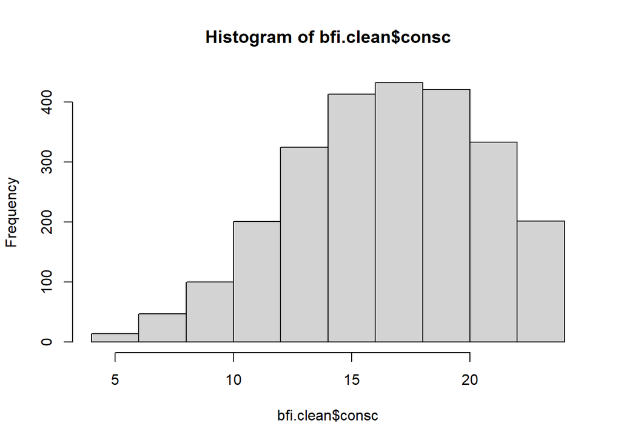

```r
consc.key = list(consc = c("C2", "C2", "C3", "-C4", "-C5")) #reverse scored items are marked with negative
consc.scores = scoreItems(consc.key, select(bfi.clean, C1:C5), totals = T, min = 1, max = 6)
bfi.clean$consc <- consc.scores$scores

hist(bfi.clean$consc)
```

Next, we will check the reliabilities of our conscientiousness measure. Cronbach’s alpha is predominantly reported in psychometric data; however, there has recently been a push away from this measure due to it’s assumption of tau-equivalence which assumes that each question is equally adept at assessing the underlying construct. Meeting this assumption is highly unlikely in the context of psychological data due to a variety of factors including question quality and clarity and how the participants interpret the questions in the context of their own experiences. Failure to meet tau-equivalence results in an underestimate of reliability. An alternative reliability measure is McDonald’s omega which uses factor analysis is not subject to the same tau-equivalence assumption. Specifically, we will use hierarchical omega. While we endeavor for our survey questions to probe a single construct (or factor), inevitably, minor factors such as similar wording among questions or question contents overlapping with another construct are likely present. Hierarchical omega can accomodate these minor factors [(Kelley & Pornprasertmanit, 2016)](https://pubmed.ncbi.nlm.nih.gov/26962759/). We will calculate and report both reliability measures for easier comparison of results with the existing literature.

Finally, we will also calculate 95% confidence intervals for both reliability measures. Following reccomedations from [Kelley and Pornprasertmanit](https://pubmed.ncbi.nlm.nih.gov/26962759/) we will use a bootstrapped method; however, these calculations can take some time depending on the computing power available, so code is also provided for a quicker but potentially less accurate estimate.

```r
###### Reliability Measures
#Determine reliability of conscientiousness measure
consc <- select(bfi.clean, C1:C5) #take subset of conscientiousness questions
consc$C4 <- (7 - consc$C4) #flip scoring of reverse scored items: (max_score + 1) - score
consc$C5 <- (7 - consc$C5)

#reliability and bootstrapped confidence intervals, long to process, best for publication
consc.alpha <- ci.reliability(consc, type = 'alpha', interval.type = "bca")
consc.alpha
```

```
## $est
## [1] 0.723729
##
## $se
## [1] 0.009592927
##
## $ci.lower
## [1] 0.7044127
##
## $ci.upper
## [1] 0.7418797
##
## $conf.level
## [1] 0.95
##
## $type
## [1] "alpha"
##
## $interval.type
## [1] "bca bootstrap"
```

```r
consc.omegah <- ci.reliability(consc, type = 'hierarchical', interval.type = "bca")
consc.omegah
```

```
## $est
## [1] 0.7284345
##
## $se
## [1] 0.009424152
##
## $ci.lower
## [1] 0.7091323
##
## $ci.upper
## [1] 0.7463521
##
## $conf.level
## [1] 0.95
##
## $type
## [1] "hierarchical omega"
##
## $interval.type
## [1] "bca bootstrap"
```

```r
#reliability estimates with quick confidence intervals
consc.alpha.quick <- ci.reliability(consc, type ='alpha', interval.type = 'feldt')
consc.alpha.quick
```

```
## $est
## [1] 0.723729
##
## $se
## [1] NA
##
## $ci.lower
## [1] 0.7061859
##
## $ci.upper
## [1] 0.7405297
##
## $conf.level
## [1] 0.95
##
## $type
## [1] "alpha"
##
## $interval.type
## [1] "feldt"
```

```r
consc.omegah.quick <- ci.reliability(consc, type = 'hierarchical', interval.type = 'icc')
consc.omegah.quick
```

```
## $est
## [1] 0.7284345
##
## $se
## [1] 0.03169895
##
## $ci.lower
## [1] 0.7110273
##
## $ci.upper
## [1] 0.7447931
##
## $conf.level
## [1] 0.95
##
## $type
## [1] "hierarchical omega"
##
## $interval.type
## [1] "intraclass correlation"
```

Next, we can move on to our regression. By calculating a composite conscientiousness score by summing our likert items we have already assumed equal distance between likert scores and are justified in treating the resulting scores as continuous. We will use linear regression using age, gender, and education as predictor variables. Age is a continuous predictor, gender a binary (in this context), and education ordinal with 5 levels.

```r
##### Regression
#create a model using age, gender, and education to predict conscientiousness

model0 <- lm(data = bfi.clean, consc ~ 1) #null model
summary(model0)
```

```
##
## Call:
## lm(formula = consc ~ 1, data = bfi.clean)
##
## Residuals:
##     Min      1Q  Median      3Q     Max
## -12.955  -2.955   0.045   3.045   7.045
##
## Coefficients:
##             Estimate Std. Error t value Pr(>|t|)
## (Intercept) 16.95498    0.08104   209.2   <2e-16 ***
## ---
## Signif. codes:  0 '***' 0.001 '**' 0.01 '*' 0.05 '.' 0.1 ' ' 1
##
## Residual standard error: 4.042 on 2487 degrees of freedom
```

```r
model1 <- lm(data = bfi.clean, consc ~ age + gender + education)
summary(model1)
```

```
##
## Call:
## lm(formula = consc ~ age + gender + education, data = bfi.clean)
##
## Residuals:
##      Min       1Q   Median       3Q      Max
## -13.2882  -2.7167   0.3449   3.0241   8.4501
##
## Coefficients:
##                           Estimate Std. Error t value Pr(>|t|)
## (Intercept)              14.848695   0.346311  42.877  < 2e-16 ***
## age                       0.038958   0.007875   4.947 8.03e-07 ***
## genderfemale              0.756062   0.171822   4.400 1.13e-05 ***
## educationHS              -0.024874   0.364495  -0.068  0.94560
## educationsome college     0.904239   0.296005   3.055  0.00228 **
## educationcollege         -0.099144   0.345507  -0.287  0.77417
## educationgraduate degree  0.129602   0.345367   0.375  0.70750
## ---
## Signif. codes:  0 '***' 0.001 '**' 0.01 '*' 0.05 '.' 0.1 ' ' 1
##
## Residual standard error: 3.989 on 2481 degrees of freedom
## Multiple R-squared:  0.02864,    Adjusted R-squared:  0.02629
## F-statistic: 12.19 on 6 and 2481 DF,  p-value: 1.483e-13
```

```r
anova(model0, model1)
```

```
## Analysis of Variance Table
##
## Model 1: consc ~ 1
## Model 2: consc ~ age + gender + education
##   Res.Df   RSS Df Sum of Sq      F    Pr(>F)
## 1   2487 40639
## 2   2481 39475  6    1163.8 12.191 1.483e-13 ***
## ---
## Signif. codes:  0 '***' 0.001 '**' 0.01 '*' 0.05 '.' 0.1 ' ' 1
```

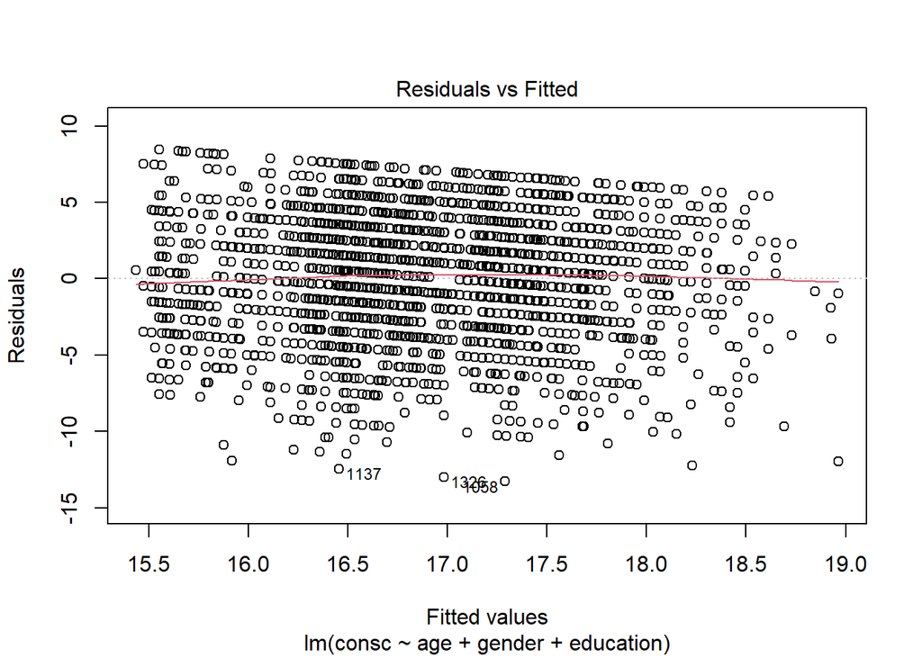

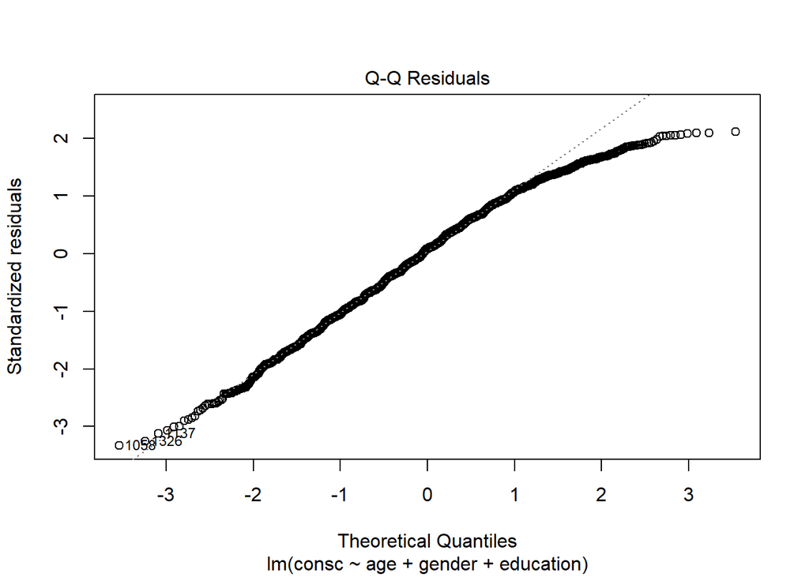

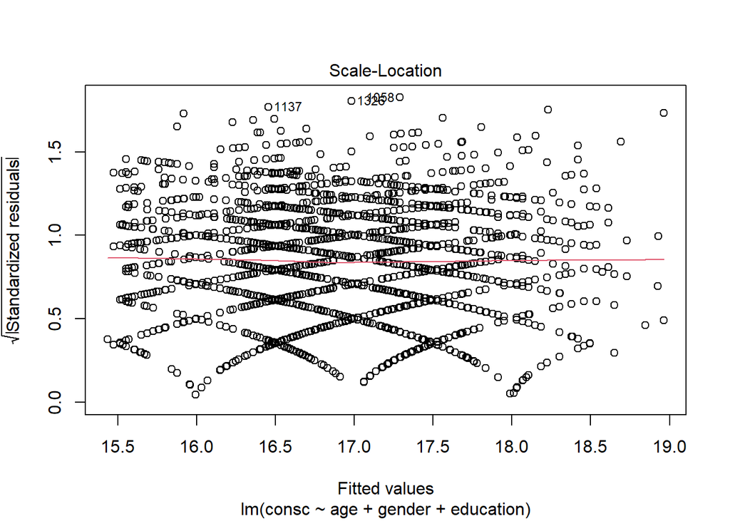

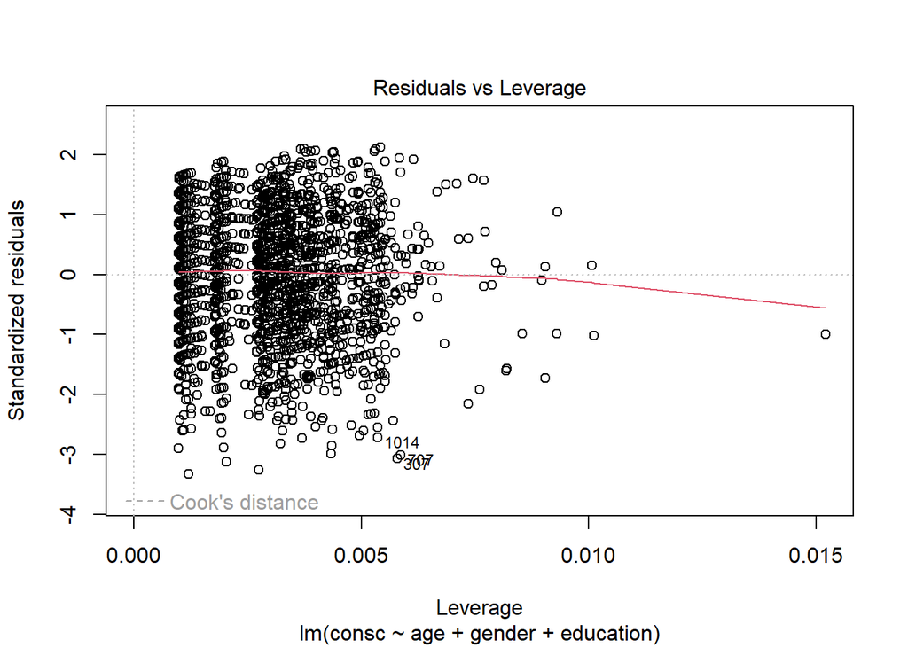

```r
plot(model1) #plot residuals to verify assumptions
```

```r
#Plot 1 = linearity assumption, good is red line is horizontal/flat
#Plot 2 = normality assumption, good is follows diagonal line
#Plot 3 = homoscedasticity, good is red line is horizontal/flat
#Plot 4 = outliers.


vif(model1) #check variance inflation factor to ensure no interaction between predictor terms
```

```
##               GVIF Df GVIF^(1/(2*Df))
## age       1.122471  1        1.059467
## gender    1.013003  1        1.006480
## education 1.129145  4        1.015298
```

Before we examine our model, let’s first examine our plots of residuals and variance inflation factor. In our Residuals vs Fitted plot, our points are reasonably evenly distributed. The Q-Q plot shows a slight-left skew reflective of our left-skewed distribution of conscientious scores; fortunately, our sample size is large enough that we do not need to worry about this skew significantly affecting our regression results. Our Scale-Location plot shows an interesting pattern; however, this pattern is most likely an artifact of our conscientious score having discrete whole number values. Finally, the Residuals vs Leverage plot shows nothing of concern. The three most influential points are participants with high ages (59, 64, and 65) with low conscientiousness scores (6 or 7) and there is no justification for dropping them. Finally, the variance inflation factor of our predictors are low values (~1) thus our predictors are uncorrelated. Subsequently, we are able to interpret our regression results without worry.

### Visualisation

First, we will create a data frame with proper punctuation and full length variable names.

```r
bfi.vis <- select(bfi.clean, gender:age, consc) #create subset for visualizations

bfi.vis <-
  rename(bfi.vis,
         Gender = gender,
         Education = education,
         Age = age,
         Conscientiousness = consc
         )


bfi.vis$Education <- factor(bfi.vis$Education,
                            levels = c("some HS", "HS", "some college", "college", "graduate degree"),
                            labels = c("Some High School", "High School", "Some College", "College", "Graduate Degree"))

bfi.vis$Gender <- factor(bfi.vis$Gender,
                         levels = c("male", "female"),
                         labels = c("Male", "Female"))
```

Next, we will create a consistent color palette to differentiate the two levels of gender across our visuals. Also included is code for when you have more than two levels to a variable and want to use a color palette set such as RColorBrewer.

```r
#######Crate consistent color palette

#Use a color palette, best if you have variables with more levels
#mycolors <- brewer.pal(2, "Set1")
#names(mycolors) <- levels(bfi.clean$gender)
#gendercolors <- scale_colour_manual(name = "gender", values = mycolors) #store for scatter plots
#gendercolorsbar <- scale_fill_manual(name = "gender", values = mycolors) #store for bar charts

#Assign a specific color to each gender
gendercolors <- scale_colour_manual(values = c("Male" = "#008080", "Female" = "#cc5500")) #store for scatter plots
gendercolorsbar <- scale_fill_manual(values = c("Male" = "#008080", "Female" = "#cc5500")) #store for bar charts
```

In order to efficiently describe the demographics of our sample, we will create a population pyramid.

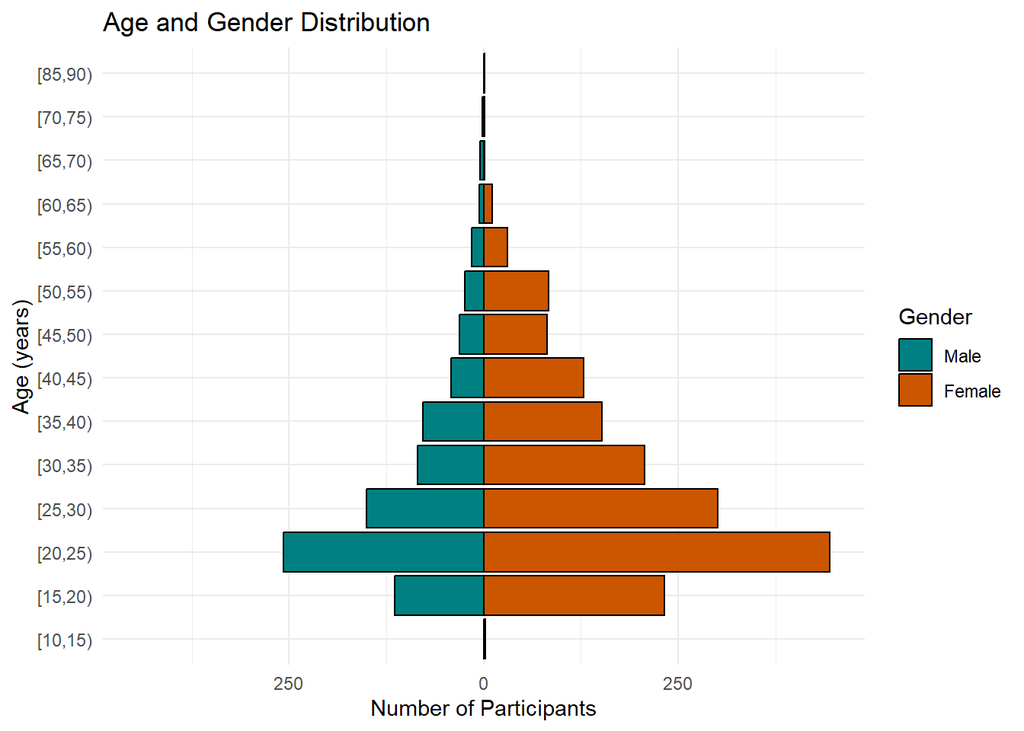

```r
####### Create population pyramid
bins.age <- seq(from = 0, to = 100, by = 5) #define bin size

gender.age <- select(bfi.vis, Gender, Age) #select Gender and Age

gender.age$age_group <- cut(gender.age$Age, bins.age, include.lowest = T, right = F) #organize in bins

pop.pyramid <- gender.age %>%
  group_by(Gender) %>%
  count(age_group) %>%
  arrange(Gender) #arrange Male first for consistent legend format

plot1 <- ggplot(
  pop.pyramid,
  aes(
    x = age_group,
    fill = Gender,
    y = ifelse(               #separate Males and Females
      test = Gender =="Male",
      yes = -n, #puts Males on left
      no = n
    )
  )
) +
  geom_bar(stat = "identity", color = "black")+
  gendercolorsbar

plot.pop.pyramid <- plot1 +
  scale_y_continuous(
    labels = abs,       #plot absolute values to remove negative used above
    limits = max(pop.pyramid$n) *c(-1,1) #create symetrical limits
  ) +
  theme_minimal()+
  coord_flip()+
  labs(
    x = "Age (years)",
    y = "Number of Participants",
    fill = "Gender",
    title = "Age and Gender Distribution"

  )
plot.pop.pyramid
```

Next, we will create a bar chart to show education level by gender.

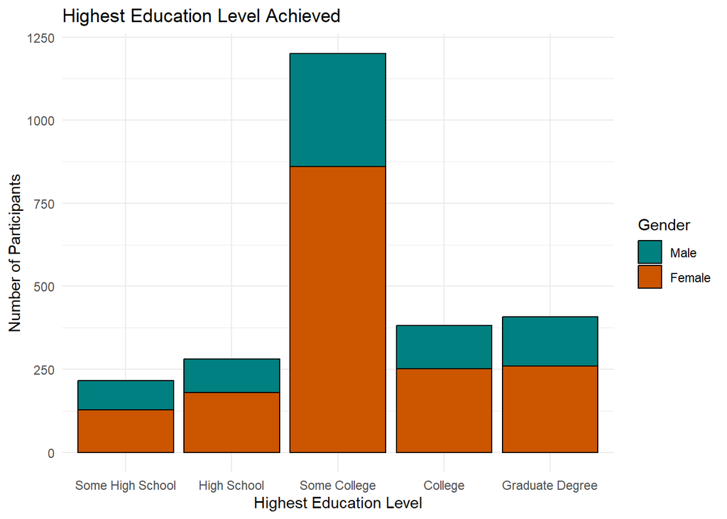

```r
edu.gender <- select(bfi.vis, Gender, Education) #create subset
edu.gender.count <- edu.gender %>%
  group_by(Gender) %>%  #group by Gender
  count(Education)     #count participants with each level of education




plot.edu.gender <- ggplot(edu.gender.count, aes(fill = Gender, y= n, x=Education))+
  geom_bar(position = "stack", stat = "identity", color = "black")+
  labs(y= "Number of Participants", x="Highest Education Level")+
  ggtitle("Highest Education Level Achieved")+
  theme_minimal()+
  gendercolorsbar

plot.edu.gender
```

Next, we will create a bar chart to show conscientiousness by gender.

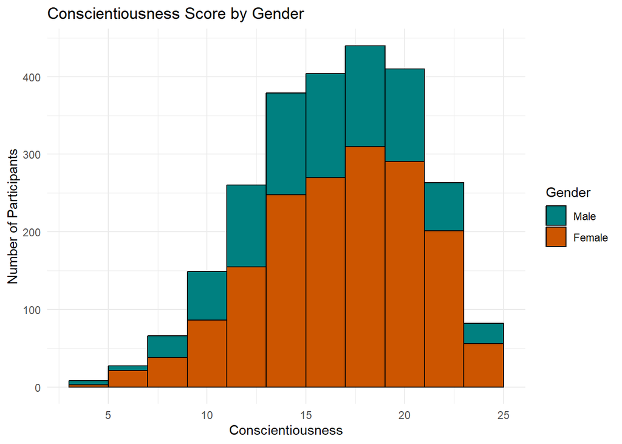

```r
plot.consc.gender <- ggplot(bfi.vis, aes(fill = Gender, x= Conscientiousness ))+
  geom_histogram(binwidth = 2, color = "black")+
  labs(y = "Number of Participants")+
  theme_minimal()+
  ggtitle("Conscientiousness Score by Gender")+
  gendercolorsbar
plot.consc.gender
```

Finally, we will create a violin plot showing conscientiousness scores collapsed across gender

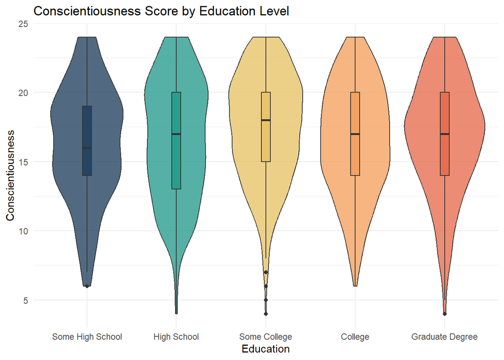

```r
vio.colors <- c("#264563", "#2a9d8f", "#e9c46a", "#f4a261", "#e76f51")

plot.consc.edu <- ggplot(bfi.vis, aes( y = Conscientiousness, x = Education, fill = Education))+
  geom_violin(alpha = 0.8)+
  geom_boxplot(width = 0.1)+
  scale_fill_manual(values = vio.colors)+
  theme_minimal()+
  theme(legend.position = "none")+
  ggtitle("Conscientiousness Score by Education Level")

plot.consc.edu
```

### Key Information for Presentation

Now that we have completed our analysis and created our visualizations, we can print our key information for our presentation and export high resolution images of our visualizations.

```r
#summary statistics
summary(bfi.vis) #easy descriptors of key variables
```

```
##     Gender                Education         Age        Conscientiousness.consc
##  Male  : 809   Some High School: 216   Min.   :14.00   Min.   : 4.0000000000
##  Female:1679   High School     : 281   1st Qu.:21.00   1st Qu.:14.0000000000
##                Some College    :1201   Median :26.00   Median :17.0000000000
##                College         : 382   Mean   :29.68   Mean   :16.9549839228
##                Graduate Degree : 408   3rd Qu.:36.00   3rd Qu.:20.0000000000
##                                        Max.   :86.00   Max.   :24.0000000000
```

```r
tapply(bfi.vis$Conscientiousness, bfi.vis$Gender, summary) #conscientiousness by gender
```

```
## $Male
##    Min. 1st Qu.  Median    Mean 3rd Qu.    Max.
##    4.00   13.00   16.00   16.36   20.00   24.00
##
## $Female
##    Min. 1st Qu.  Median    Mean 3rd Qu.    Max.
##    4.00   14.50   18.00   17.24   20.00   24.00
```

```r
tapply(bfi.vis$Age, bfi.vis$Gender, summary) #age by gender
```

```
## $Male
##    Min. 1st Qu.  Median    Mean 3rd Qu.    Max.
##   15.00   21.00   25.00   28.91   35.00   74.00
##
## $Female
##    Min. 1st Qu.  Median    Mean 3rd Qu.    Max.
##   14.00   21.00   27.00   30.05   37.00   86.00
```

```r
tapply(bfi.vis$Education, bfi.vis$Gender, summary) #education by gender
```

```
## $Male
## Some High School      High School     Some College          College
##               88              101              341              130
##  Graduate Degree
##              149
##
## $Female
## Some High School      High School     Some College          College
##              128              180              860              252
##  Graduate Degree
##              259
```

```r
#reliability measures
consc.alpha #alpha with bootstrapped 95%CI for best report
```

```
## $est
## [1] 0.723729
##
## $se
## [1] 0.009592927
##
## $ci.lower
## [1] 0.7044127
##
## $ci.upper
## [1] 0.7418797
##
## $conf.level
## [1] 0.95
##
## $type
## [1] "alpha"
##
## $interval.type
## [1] "bca bootstrap"
```

```r
consc.omegah #hierarchical omega with boostrapped 95%CI for best report
```

```
## $est
## [1] 0.7284345
##
## $se
## [1] 0.009424152
##
## $ci.lower
## [1] 0.7091323
##
## $ci.upper
## [1] 0.7463521
##
## $conf.level
## [1] 0.95
##
## $type
## [1] "hierarchical omega"
##
## $interval.type
## [1] "bca bootstrap"
```

```r
consc.alpha.quick #alpha with Feldt 95%CI for quick report
```

```
## $est
## [1] 0.723729
##
## $se
## [1] NA
##
## $ci.lower
## [1] 0.7061859
##
## $ci.upper
## [1] 0.7405297
##
## $conf.level
## [1] 0.95
##
## $type
## [1] "alpha"
##
## $interval.type
## [1] "feldt"
```

```r
consc.omegah.quick #hierarchical omega with icc 95%CI for quick report
```

```
## $est
## [1] 0.7284345
##
## $se
## [1] 0.03169895
##
## $ci.lower
## [1] 0.7110273
##
## $ci.upper
## [1] 0.7447931
##
## $conf.level
## [1] 0.95
##
## $type
## [1] "hierarchical omega"
##
## $interval.type
## [1] "intraclass correlation"
```

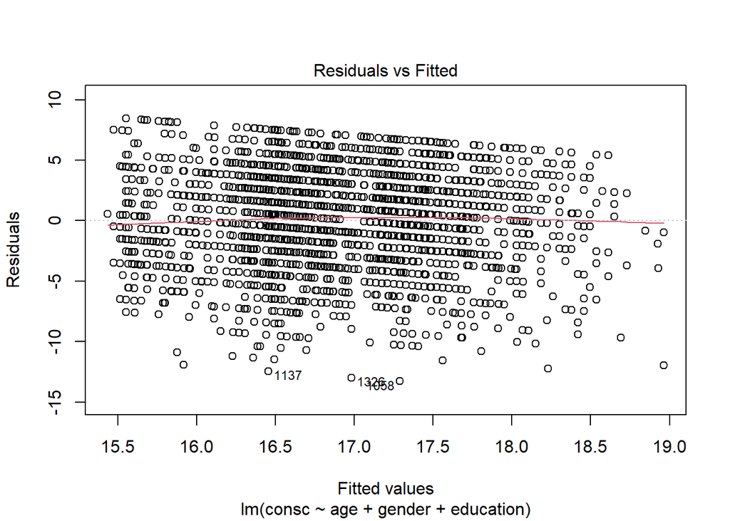

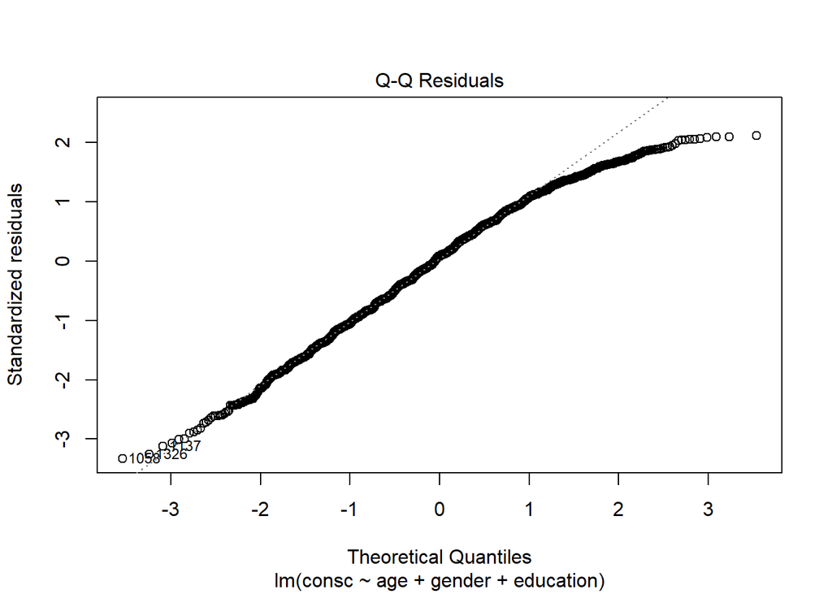

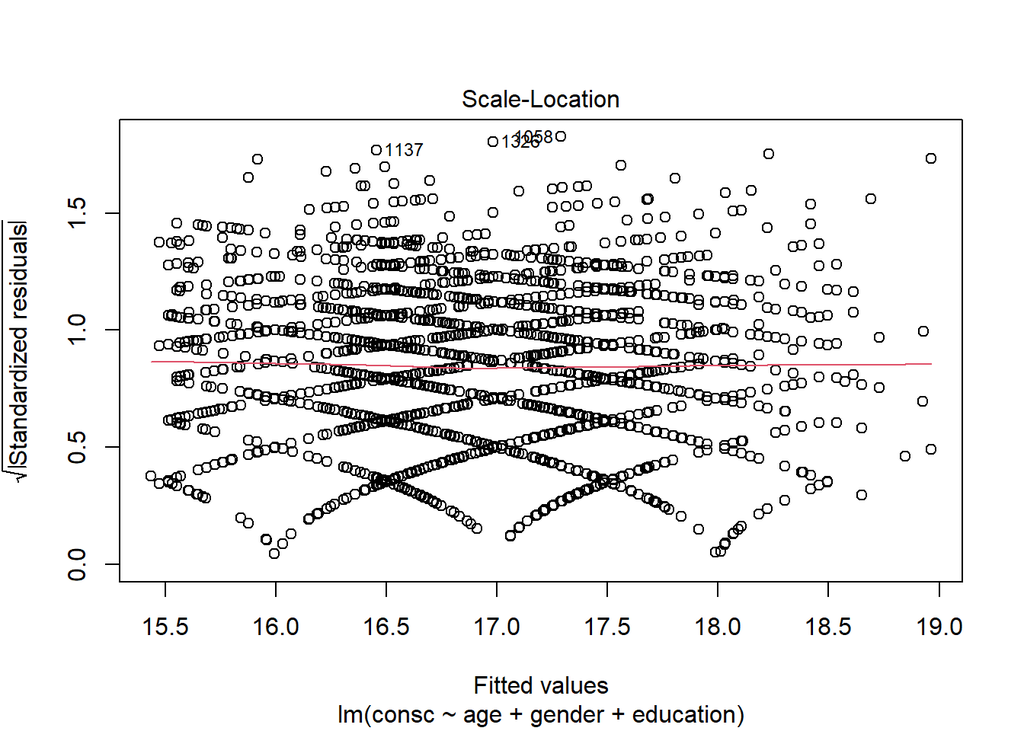

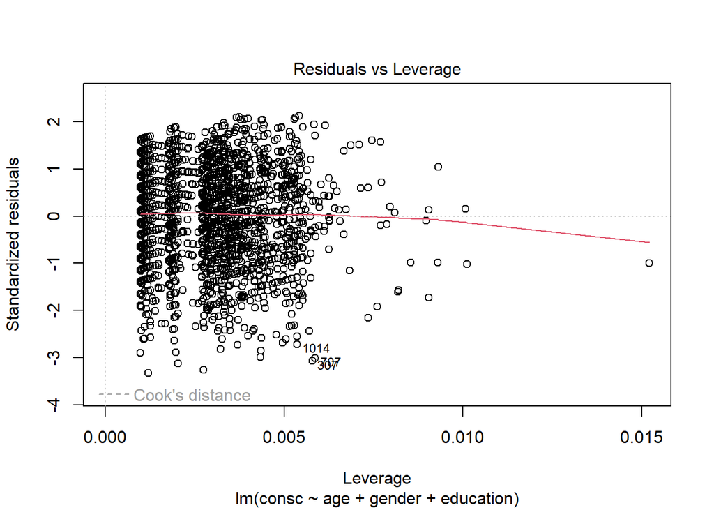

```r
#regression
plot(model1) #assumptions check reporting
```

```r
summary(model1) #model report
```

```
##
## Call:
## lm(formula = consc ~ age + gender + education, data = bfi.clean)
##
## Residuals:
##      Min       1Q   Median       3Q      Max
## -13.2882  -2.7167   0.3449   3.0241   8.4501
##
## Coefficients:
##                           Estimate Std. Error t value Pr(>|t|)
## (Intercept)              14.848695   0.346311  42.877  < 2e-16 ***
## age                       0.038958   0.007875   4.947 8.03e-07 ***
## genderfemale              0.756062   0.171822   4.400 1.13e-05 ***
## educationHS              -0.024874   0.364495  -0.068  0.94560
## educationsome college     0.904239   0.296005   3.055  0.00228 **
## educationcollege         -0.099144   0.345507  -0.287  0.77417
## educationgraduate degree  0.129602   0.345367   0.375  0.70750
## ---
## Signif. codes:  0 '***' 0.001 '**' 0.01 '*' 0.05 '.' 0.1 ' ' 1
##
## Residual standard error: 3.989 on 2481 degrees of freedom
## Multiple R-squared:  0.02864,    Adjusted R-squared:  0.02629
## F-statistic: 12.19 on 6 and 2481 DF,  p-value: 1.483e-13
```

```r
#regression table
modelvis <- lm(data = bfi.vis, Conscientiousness ~ Age + Gender + Education)
reg.table <- tbl_regression(modelvis) %>% # create regression table
  bold_p() %>%
  add_glance_table(include = c("r.squared", "adj.r.squared", "nobs", "statistic" , "p.value"))
reg.table
```

| **Characteristic** | **Beta** | **95% CI** | **p-value** |
| --- | --- | --- | --- |
| Age | 0.04 | 0.02, 0.05 | <0.001 |
| Gender |  |  |  |
| Male | — | — |  |
| Female | 0.76 | 0.42, 1.1 | <0.001 |
| Education |  |  |  |
| Some High School | — | — |  |
| High School | -0.02 | -0.74, 0.69 | >0.9 |
| Some College | 0.90 | 0.32, 1.5 | 0.002 |
| College | -0.10 | -0.78, 0.58 | 0.8 |
| Graduate Degree | 0.13 | -0.55, 0.81 | 0.7 |
| R² | 0.029 |  |  |
| Adjusted R² | 0.026 |  |  |
| No. Obs. | 2,488 |  |  |
| Statistic | 12.2 |  |  |
| p-value | <0.001 |  |  |

Abbreviation: CI = Confidence Interval

```r
as_gt(reg.table) %>% # save .png of regression table
gt::gtsave(filename = "consc_reg_table.png")
```

```
## file:///C:/Users/krist/AppData/Local/Temp/RtmpU9DQvP/file5a887d9b3cf6.html screenshot completed
```

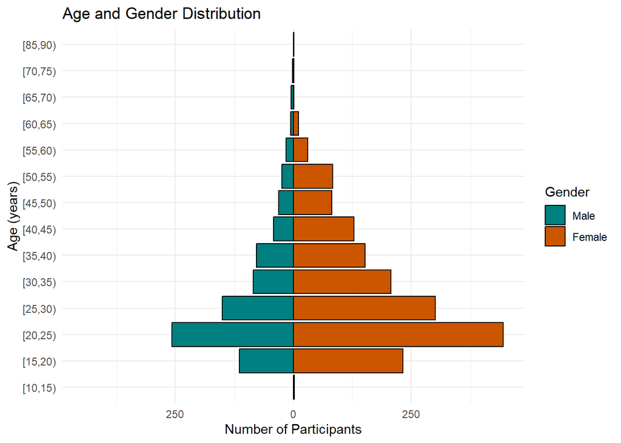

```r
# Figures
plot.pop.pyramid #population pyramid showing gender and age distribution of sample
```

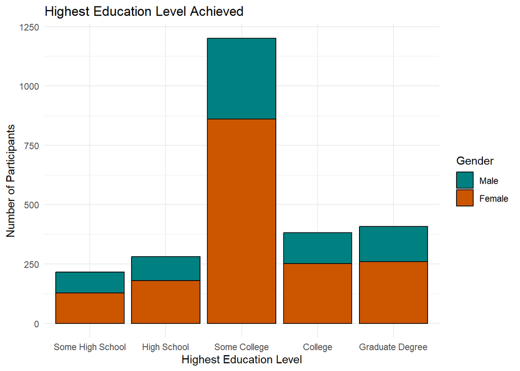

```r
ggsave("Population_Pyramid.png", plot = plot.pop.pyramid, width = 15, height = 12, units = "cm")

plot.edu.gender #bar chart showing education level of sample by gender
```

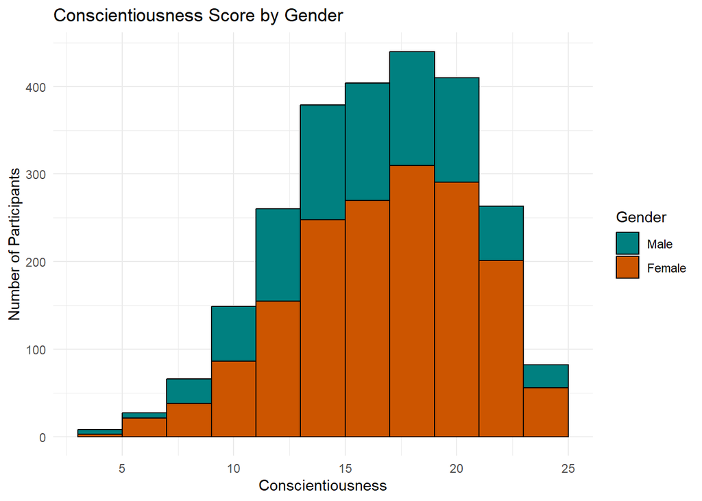

```r
ggsave("Education_Level.png", plot = plot.edu.gender, width = 17, height = 12, units = "cm")

plot.consc.gender #histogram showing conscientiousness score by gender
```

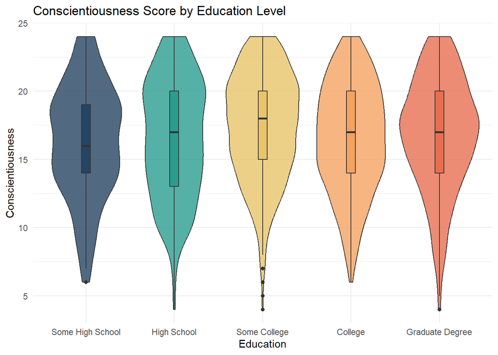

```r
ggsave("Conscientiousness_Histogram.png", plot = plot.consc.gender, width = 15, height = 12, units = "cm")

plot.consc.edu #violin plot showing conscientiousness by education
```

```r
ggsave("Conscentious_Education.png", plot = plot.consc.edu, width = 17, height = 12, units = "cm")
```

### Conclusion

The results of our survey show that generally, females report as more conscientious than males, and that conscientiousness tends to increase with age. However, our sample also shows an unexpected result: In comparison to our reference education level, the only level of education that showed a significant difference in conscientiousness was “some college” and not those who had completed college or obtained a graduate degree. This is counter to what would be expected as conscientiousness is considered a predictor of higher-education success and thus you would expect to find higher levels of this personality trait present in the higher education population [(Roberts et al., 2014)](https://pubmed.ncbi.nlm.nih.gov/23276130/).